# SPSP Data visual

Heather Hawkins

2023-02-16

I wanted to make a nice clean visual for my SPSS poster, so I decided to do this in R.

## Loading Packages and Data

My poster was about my first year project. It was a replication of another study that focused on Culpability and Agency. Everything was related to COVID. There were 2 scenarios, Bars and resturants (where students had to choose (high agency) or were told (low agency) to reopen them or close them) and delivery workers ( where students had to choose to allow untested workers to deliver or to not allow them to deliver). Basically, the study found that those with High Agency felt worse about the outcome of 20 people dying than those with Low Agency.

Because this was my first year project, the data was sorted and cleaned in SPSS. So, I had to import the data into R.

```r
library(tidyverse)
```

```r
library(ggeasy)
library(ggplot2)
library(skimr)
library(haven)
CulpAndCount <- read_sav("~/Documents/Situational-assessment Study_February 15, 2023_22.16.sav")

#view class of data
class(CulpAndCount)
```

```
## [1] "tbl_df"     "tbl"        "data.frame"
```

```r
#display dimensions of data frame
dim(CulpAndCount)
```

```
## [1] 121 130
```

```r
#view first six rows of data
head(CulpAndCount)
```

```
## # A tibble: 6 × 130
##   StartDate           EndDate             Status         IPAdd…¹ Progr…² Durat…³
##   <dttm>              <dttm>              <dbl+lbl>      <chr>     <dbl>   <dbl>
## 1 2022-04-08 07:45:56 2022-04-08 08:13:31 0 [IP Address] 152.17…     100    1655
## 2 2022-04-08 14:11:07 2022-04-08 14:36:41 0 [IP Address] 152.17…     100    1534
## 3 2022-04-12 06:54:25 2022-04-12 07:13:43 0 [IP Address] 152.17…     100    1157
## 4 2022-04-14 10:57:59 2022-04-14 11:17:37 0 [IP Address] 152.17…     100    1178
## 5 2022-04-14 11:40:34 2022-04-14 12:27:01 0 [IP Address] 152.17…     100    2786
## 6 2022-04-18 09:30:05 2022-04-18 09:45:55 0 [IP Address] 152.17…     100     950
## # … with 124 more variables: Finished <dbl+lbl>, RecordedDate <dttm>,
## #   ResponseId <chr>, RecipientLastName <chr>, RecipientFirstName <chr>,
## #   RecipientEmail <chr>, ExternalReference <chr>, LocationLatitude <chr>,
## #   LocationLongitude <chr>, DistributionChannel <chr>, UserLanguage <chr>,
## #   Questions <dbl+lbl>, QuestionsAnswered <chr>, AgreeParticipate <dbl+lbl>,
## #   Q71 <dbl+lbl>, SubjectNumber <chr>, S1 <dbl+lbl>, S2Q <dbl+lbl>,
## #   BR_AG <dbl+lbl>, AS2 <dbl+lbl>, CF1 <chr>, CF2 <chr>, CF3 <chr>, …
```

```r
#
```

## 2x2x2 ANOVA

After loading the data, I had to analyze the data I had in r by labeling the levels of IVs that I had.

I had 3 IVs, Scenario, Agency, and Choice.

```r
#Labeling SCENARIO, Agency, and Choice.

CulpAndCount$Scenario <- factor(CulpAndCount$Scenario,
levels = c(1,2),
labels = c("Bars/Resturants", "Delivery Workers"))

CulpAndCount$Agency_L <- factor(CulpAndCount$Agency_L,
levels = c(1,2),
labels = c("Low Agency", "High Agency"))

CulpAndCount$Choice <- factor(CulpAndCount$Choice,
levels = c(1,2),
labels = c("Keep Close/Allow", "Reopen/Not Allow"))
```

After stating the levels, I can FINALLY make the visual.

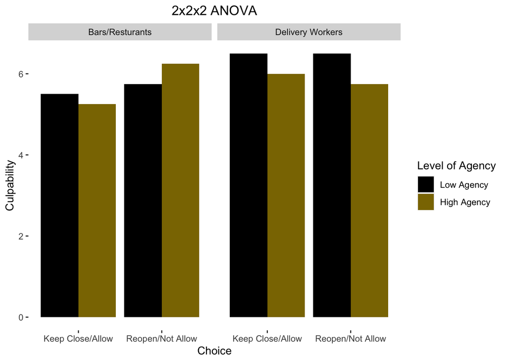

```r
CulpAndCount %>%
  ggplot(CulpAndCount, mapping = aes(x = Choice, y= Culpab, fill= Agency_L))+ facet_wrap(~Scenario)+geom_bar(stat="identity", position=position_dodge())+labs (x= "Choice", y= "Culpability")+labs(fill="Level of Agency")+ scale_fill_manual(values = c("black", "gold4"))+ labs(title= "2x2x2 ANOVA")+ theme(panel.background = element_blank())+ggeasy::easy_center_title()
```

As you can see, Keep CLose/Allow and Reopen/Not Allow were coded togeather. Logically this doesnt make too much sense as Allow and Reopen are the same thing, so why are they not coded togeather?

## Recoding the data to MAKE SENSE

```r
CulpAndCount$Choice2
```

```
##   [1] 1 1 1 1 1 1 1 1 1 2 2 2 2 2 2 2 2 2 2 2 1 1 1 1 1 1 1 1 1 1 1 1 1 1 1 1 1
##  [38] 2 2 2 2 2 2 2 2 2 2 2 2 2 2 2 2 2 2 2 2 2 2 2 2 2 2 2 2 2 2 1 1 1 1 1 1 1
##  [75] 1 1 1 1 1 1 1 1 1 1 1 1 1 2 2 2 1 1 1 1 1 1 1 1 1 1 1 1 1 2 2 2 2 2 2 2 2
## [112] 2 2 2 2 2 2 2 2 2 2
## attr(,"format.spss")
## [1] "F8.2"
## attr(,"display_width")
## [1] 10
```

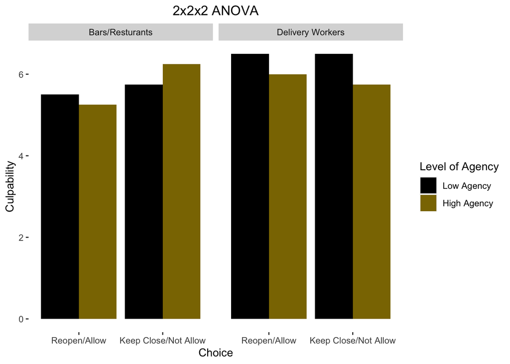

```r
CulpAndCount$Choice22 <- factor(CulpAndCount$Choice2,
levels = c(1,2),
labels = c("Reopen/Allow", "Keep Close/Not Allow"))

CulpAndCount %>%
  ggplot(CulpAndCount, mapping = aes(x = Choice22, y= Culpab, fill= Agency_L))+ facet_wrap(~Scenario)+geom_bar(stat="identity", position=position_dodge())+labs (x= "Choice", y= "Culpability")+labs(fill="Level of Agency")+ scale_fill_manual(values = c("black", "gold4"))+ labs(title= "2x2x2 ANOVA")+ theme(panel.background = element_blank())+ggeasy::easy_center_title()
```

I thought it Would make a difference. But It seems not (unless I did it wrong)